# Daily Phone Usage: A Visual Data Story

## Introduction

This project explores daily phone usage behaviour based on observational data collected from phone screen-time statistics. The dataset includes total usage time, usage category, and number of phone unlocks.

The goal of this visual data story is to understand how people use their phones and identify patterns in their behaviour.

## Relationship between Phone Usage Time and Unlocks

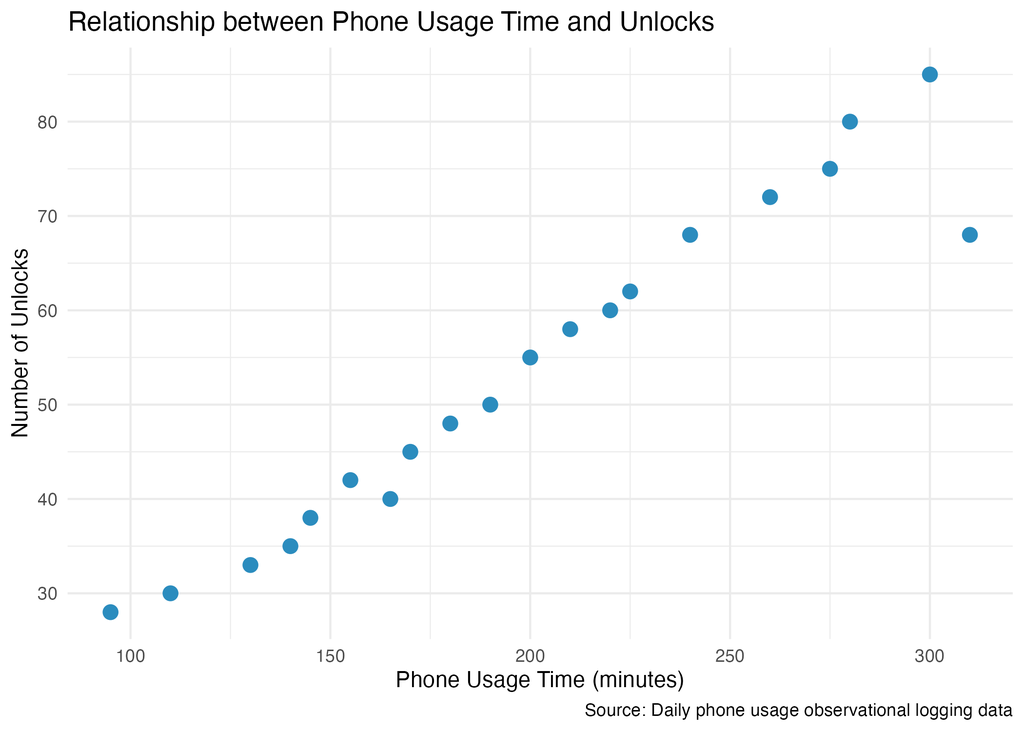

Scatter plot showing relationship between usage time and unlocks

This plot shows the relationship between phone usage time and the number of unlocks. There is a general positive trend, meaning higher usage time often leads to more unlocks.

## Distribution of Phone Usage Categories

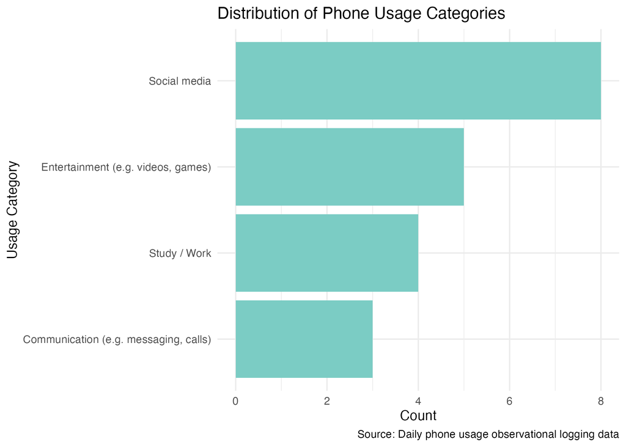

Bar chart of usage categories

This chart shows how phone usage is distributed across different categories. Social media appears most frequently, followed by entertainment and study/work.

## Average Phone Usage by Category

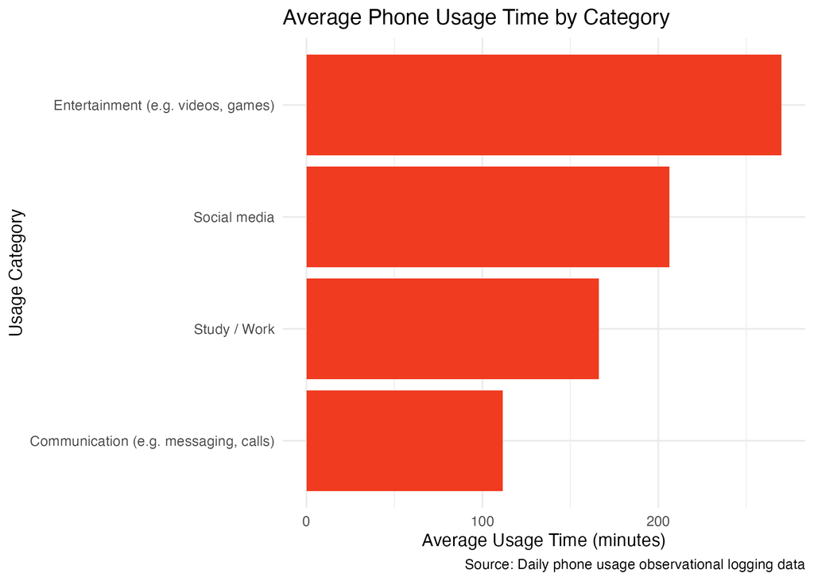

Average usage by category

This chart shows the average time spent on each category. Entertainment has the highest average usage time.

## Conclusion

Overall, phone usage behaviour varies across categories. Social media is the most common activity, while entertainment leads to longer usage time. There is also a relationship between usage time and unlock frequency.

This analysis helps us better understand daily phone usage patterns.